# Annotation QC — reviewer calibration, triage leak and the edit trail

This notebook measures the **quality-control apparatus** of the Bancada, the annotation platform in this repository, against the live working database. Every annotation goes through two independent passes: **triage** (approve or send back — the only pass that returns work to the annotator) and **Rate and Review** (rate the work as it arrived, fix it in place with a stated reason for *every* change, rate the result, justify the rating). A share of the queue is **synthetic**: machine-generated annotations that carry a hidden target rating and a planted defect family, reviewed blind. They exist to calibrate the **reviewer** — an instrument almost no annotation platform has, because measuring the person who checks the work is harder than measuring the person who does it. Everything below is computed with **the same functions** that `pf annotate export --perfil quality-report` writes to disk and that the admin dashboard serves over HTTP (`prompt_factory.annotate.entrega`), so the notebook and the platform cannot drift apart: there is one implementation of each metric, and this page is a third reader of it.

**Read-only.** Both databases are opened with `readonly=True`. Nothing here writes, and nothing here runs a pipeline stage.

```python
# O backend TEM de ser escolhido antes de qualquer figura, e tem de ser o
# `inline`. Ele é headless (renderiza por baixo com o mesmo Agg, então não
# procura display nenhum) E é o único que devolve a figura como SAÍDA DA CÉLULA,
# que é o que o nbconvert embute no HTML. `matplotlib.use("Agg")` puro também
# roda sem display — e faz `plt.show()` virar no-op: o notebook executa limpo,
# sai com código 0 e produz um HTML com ZERO gráfico. Medido aqui: 100% das
# figuras perdidas, sem um aviso sequer.
%matplotlib inline
import base64
import io
import json
from collections import Counter, defaultdict
from html import escape as escape_html

import matplotlib
import matplotlib.pyplot as plt
from IPython.display import HTML, display

# png e não svg: o HTML é commitado, e svg de histograma com dezenas de milhares
# de patches explode o arquivo.
%config InlineBackend.figure_formats = ["png"]

from prompt_factory import paths
from prompt_factory.annotate import db as adb
from prompt_factory.annotate import entrega, geracao
from prompt_factory.db import connect

plt.rcParams.update({
    "figure.dpi": 110, "savefig.dpi": 110, "font.size": 10,
    "axes.titlesize": 11, "axes.titleweight": "bold", "axes.labelsize": 10,
    "axes.spines.top": False, "axes.spines.right": False,
    "axes.grid": True, "grid.alpha": 0.25, "grid.linestyle": "-",
    "figure.facecolor": "white", "axes.facecolor": "white",
})

# Paleta fixa: humano x sintético é a distinção que atravessa o notebook inteiro.
AZUL, LARANJA, CINZA, VERDE, VERMELHO = "#2f6f9f", "#d98032", "#8c8c8c", "#4a8c5f", "#b04a4a"


def mostrar(fig, alt):
    # A figura é embutida À MÃO, com o `alt` escrito por nós. Duas alternativas
    # foram testadas e as duas falham em silêncio:
    #   * `plt.show()` sob `matplotlib.use("Agg")` é NO-OP — o notebook executa
    #     limpo, sai com código 0 e produz um HTML sem um único gráfico;
    #   * `display(fig, metadata={"image/png": {"alt": ...}})` desenha a figura e
    #     DESCARTA o alt: o bloco `data_png` do template `lab` do nbconvert lê
    #     width/height/unconfined/needs_background do metadata e não lê `alt`.
    #     O nbconvert então carimba "No description has been provided for this
    #     image" e avisa no fim da conversão.
    # Emitindo o <img> daqui, o texto alternativo é o que está escrito na chamada
    # — e o comando de render continua sendo UM, sem pós-processamento escondido
    # que quem reproduzir o notebook não teria como adivinhar.
    buf = io.BytesIO()
    fig.savefig(buf, format="png")
    plt.close(fig)          # senão o backend inline redesenha a figura no fim da célula
    b64 = base64.b64encode(buf.getvalue()).decode("ascii")
    display(HTML(f'<img alt="{escape_html(alt, quote=True)}" '
                 f'src="data:…" '
                 f'style="max-width:100%;height:auto">'))


def anotar_barras(ax, barras, valores, *, dx=0.0, dy=0.0, fmt="{:,.0f}"):
    # Todo gráfico deste notebook carrega o n em cima da barra. Um eixo sozinho
    # esconde a diferença entre "3 de 4" e "3.000 de 4.000", e aqui os n são
    # pequenos o bastante para que essa diferença seja a informação principal.
    for barra, valor in zip(barras, valores, strict=True):
        ax.annotate(fmt.format(valor),
                    (barra.get_width() + dx, barra.get_y() + barra.get_height() / 2 + dy),
                    va="center", ha="left", fontsize=9, color="#333")


# Guard: um clone sem os bancos tem de RENDERIZAR, com a mensagem no lugar do
# número. `--execute` que levanta produz um HTML pela metade, e um HTML pela
# metade é pior que um painel que diz honestamente o que falta.
TEM_BANCADA = paths.ANNOTATE_DB_FILE.exists()
TEM_CORPUS = paths.DB_FILE.exists()
PRONTO = TEM_BANCADA and TEM_CORPUS

print("matplotlib backend:", matplotlib.get_backend())
assert "inline" in matplotlib.get_backend().lower(), (
    "backend sem captura de figura: o HTML sairia sem gráfico nenhum")

conn = conn_corpus = None
if PRONTO:
    conn = connect(paths.ANNOTATE_DB_FILE, readonly=True)
    conn_corpus = connect(paths.DB_FILE, readonly=True)
    print("annotate.sqlite  :", paths.ANNOTATE_DB_FILE)
    print("prompts.sqlite   :", paths.DB_FILE)
else:
    print("MISSING — this notebook renders its structure but not its numbers.")
    print("  annotate.sqlite:", "ok" if TEM_BANCADA else f"absent ({paths.ANNOTATE_DB_FILE})")
    print("  prompts.sqlite :", "ok" if TEM_CORPUS else f"absent ({paths.DB_FILE})")
    print("  build them with:  pf load-db --allow-unlabeled-pct 100   &&   pf annotate seed")
```

```
matplotlib backend: inline
annotate.sqlite  : G:\Github\Prompt-factory\data\db\annotate.sqlite
prompts.sqlite   : G:\Github\Prompt-factory\data\db\prompts.sqlite
```

## 0. What exactly was read

An honest fingerprint of the inputs. There is **no wall clock** here on purpose: a "generated at" timestamp changes the rendered HTML on every run and tells the reader nothing about the data. What identifies the run is the state of the files.

`db_build_id` is `sha256(universe_sha + labels_sha)[:16]` — the corpus is rebuilt and swapped underneath the platform by `pf load-db`, so the id is what says *which* corpus the annotations were made against.

```python
def _fingerprint(caminho):
    if not caminho.exists():
        return {"file": str(caminho), "state": "absent"}
    st = caminho.stat()
    import datetime
    return {
        "file": str(caminho),
        "bytes": f"{st.st_size:,}",
        # mtime do ARQUIVO, não a hora de agora: é propriedade do insumo.
        "mtime_utc": datetime.datetime.fromtimestamp(
            st.st_mtime, datetime.UTC).strftime("%Y-%m-%dT%H:%M:%SZ"),
    }


if PRONTO:
    fp = {"annotate.sqlite": _fingerprint(paths.ANNOTATE_DB_FILE),
          "prompts.sqlite": _fingerprint(paths.DB_FILE)}
    fp["annotate.sqlite"]["schema_version_anotacao"] = adb.versao_do_banco(conn)
    fp["annotate.sqlite"]["expected_by_this_code"] = adb.SCHEMA_VERSION_ANOTACAO
    meta = {r["key"]: r["value"] for r in conn_corpus.execute("SELECT key, value FROM app_meta")}
    fp["prompts.sqlite"].update({
        "n_rows": f"{int(meta.get('n_rows', 0)):,}",
        "db_build_id": meta.get("db_build_id"),
        "taxonomy_version": meta.get("taxonomy_version"),
        "unlabeled_pct": meta.get("unlabeled_pct"),
    })
    pool = {r["key"]: r["value"] for r in conn.execute(
        "SELECT key, value FROM app_meta WHERE key LIKE 'pool_%'")}
    fp["prompt pool"] = {
        "origin": pool.get("pool_origem"),
        "corpus_build_it_was_built_from": pool.get("pool_db_build_id"),
        "rows_excluded_by_license_policy": pool.get("pool_excluidas_licenca"),
    }
    print(json.dumps(fp, indent=2, ensure_ascii=False))
    if fp["prompt pool"]["corpus_build_it_was_built_from"] != meta.get("db_build_id"):
        print("\nNOTE: the materialised pool was built from a DIFFERENT corpus build "
              "than the one on disk. The platform rebuilds it when the signature changes.")
else:
    print("skipped — no database")
```

```
{
  "annotate.sqlite": {
    "file": "G:\\Github\\Prompt-factory\\data\\db\\annotate.sqlite",
    "bytes": "1,069,056",
    "mtime_utc": "2026-08-11T18:37:50Z",
    "schema_version_anotacao": 6,
    "expected_by_this_code": 7
  },
  "prompts.sqlite": {
    "file": "G:\\Github\\Prompt-factory\\data\\db\\prompts.sqlite",
    "bytes": "930,050,048",
    "mtime_utc": "2026-08-12T21:26:45Z",
    "n_rows": "159,733",
    "db_build_id": "1c3fe0dc3f813ec7",
    "taxonomy_version": "1.0",
    "unlabeled_pct": "0.1174"
  },
  "prompt pool": {
    "origin": "fallback",
    "corpus_build_it_was_built_from": "495fd5bcde334f67",
    "rows_excluded_by_license_policy": "9148"
  }
}

NOTE: the materialised pool was built from a DIFFERENT corpus build than the one on disk. The platform rebuilds it when the signature changes.
```

## 1. Two different questions: what would ship, and what exists

These are not the same set, and conflating them is the easiest way to make a QC report flatter itself.

- **`entrega.coletar(...)`** answers *"what would ship right now?"*. It admits only `status = 'avaliada'` — the single terminal state of acceptance in `db.TRANSICOES`, i.e. the item cleared **both** passes. With `incluir_pendentes=True` it also admits `pendente_avaliacao` (cleared triage, second pass not done); with `incluir_sinteticas=True` the synthetic items are not filtered out. Both flags are set below because that is exactly what the admin dashboard uses — the defaults are the *delivery* defaults, and this notebook is describing the **workshop**.
- **The operational ledger** — plain `SELECT`s below — answers *"what is in the platform, in whatever state?"*. Work sent back by triage, work waiting to be triaged, and synthetic items still queued all live here and in none of the delivery profiles.

The gap between the two is the honest picture of a platform mid-flight.

```
entrega.coletar(incluir_sinteticas=True, incluir_pendentes=True) -> 7 annotation(s) in a deliverable state
    #4  sft_resposta     pendente_avaliacao   synthetic=False corrected=False
    #7  avaliar_rubrica  avaliada             synthetic=False corrected=True
    #9  avaliar_rubrica  pendente_avaliacao   synthetic=True  corrected=False
    #10  avaliar_rubrica  pendente_avaliacao   synthetic=True  corrected=False
    #11  avaliar_rubrica  pendente_avaliacao   synthetic=True  corrected=False
    #12  avaliar_rubrica  pendente_avaliacao   synthetic=True  corrected=False
    #13  conversa_modelo  pendente_avaliacao   synthetic=False corrected=False

operational ledger: 31 annotation(s) in the platform, all states
  of which deliverable today: 7 (23% of 31)
```

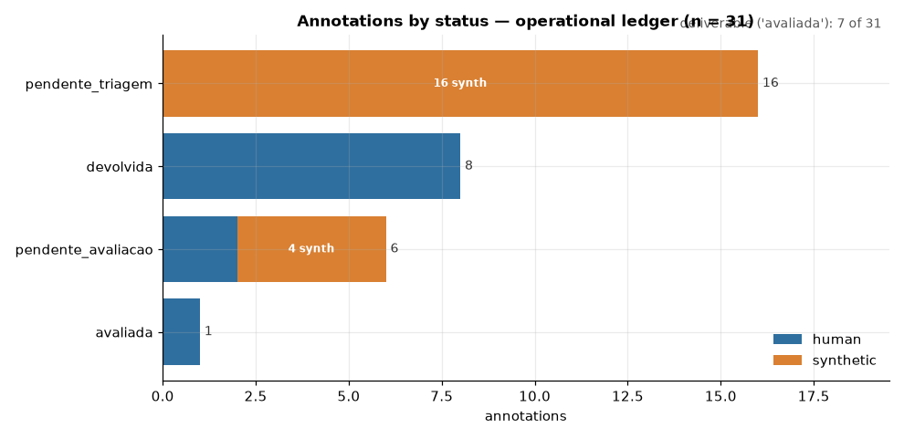

```
states with zero rows today: escalada, descartada
```

```python
if PRONTO:
    # Os dois True: mesmo conjunto que /api/admin/metricas monta.
    itens = entrega.coletar(conn, conn_corpus,
                            incluir_sinteticas=True, incluir_pendentes=True)
    print(f"entrega.coletar(incluir_sinteticas=True, incluir_pendentes=True) "
          f"-> {len(itens)} annotation(s) in a deliverable state")
    for i in itens:
        print(f"    #{i['anotacao_id']}  {i['tipo']:<16} {i['status']:<20} "
              f"synthetic={i['sintetica']!s:<5} corrected={i['corrigido']}")

    # ------------------------------------------------------------------ ledger
    # "operational ledger view": SELECT próprio, fora de `entrega`, porque
    # `entrega` só enxerga o que é entregável — que é a função dele.
    ledger = defaultdict(lambda: {"human": 0, "synthetic": 0})
    for r in conn.execute(
        "SELECT status, (gabarito_avaliacao_json IS NOT NULL) AS sint, count(*) AS n "
        "FROM anotacoes GROUP BY 1, 2"
    ):
        ledger[r["status"]]["synthetic" if r["sint"] else "human"] += r["n"]
    total_ledger = sum(v["human"] + v["synthetic"] for v in ledger.values())
    entregaveis = len(itens)

    print(f"\noperational ledger: {total_ledger} annotation(s) in the platform, all states")
    print(f"  of which deliverable today: {entregaveis} "
          f"({entregaveis / total_ledger:.0%} of {total_ledger})")

    ordem = [s for s in adb.STATUS_ANOTACAO if s in ledger]
    ordem += [s for s in ledger if s not in ordem]          # status desconhecido nunca some
    humanos = [ledger[s]["human"] for s in ordem]
    sints = [ledger[s]["synthetic"] for s in ordem]

    fig, ax = plt.subplots(figsize=(9, 0.62 * len(ordem) + 1.9))
    b1 = ax.barh(ordem, humanos, color=AZUL, label="human")
    b2 = ax.barh(ordem, sints, left=humanos, color=LARANJA, label="synthetic")
    for y, (h, s) in enumerate(zip(humanos, sints, strict=True)):
        ax.annotate(f"{h + s}", (h + s + 0.12, y), va="center", fontsize=9, color="#333")
        if s:
            ax.annotate(f"{s} synth", (h + s / 2, y), va="center", ha="center",
                        fontsize=8, color="white", weight="bold")
    ax.set_xlim(0, max(h + s for h, s in zip(humanos, sints, strict=True)) * 1.22)
    ax.invert_yaxis()
    ax.set_xlabel("annotations")
    ax.set_title(f"Annotations by status — operational ledger (n = {total_ledger})")
    ax.legend(loc="lower right", frameon=False)
    ax.annotate(
        f"deliverable ('avaliada'): {entregaveis} of {total_ledger}",
        xy=(0.99, 1.02), xycoords="axes fraction", ha="right", fontsize=9, color="#555")
    plt.tight_layout()
    mostrar(fig, "Horizontal stacked bar of annotations by workflow status, split into human and synthetic segments, with the count printed on each bar.")

    faltando = [s for s in adb.STATUS_ANOTACAO if s not in ledger]
    if faltando:
        print("states with zero rows today: " + ", ".join(faltando))
else:
    itens, ledger, total_ledger = [], {}, 0
    print("skipped — no database")
```

## 2. Human and synthetic, declared rather than inferred

The signal that an annotation is machine-generated is **one column**, and the singleness is the decision: `anotacoes.gabarito_avaliacao_json IS NOT NULL`. Two marks would eventually disagree, and on the day they disagreed nobody would know which to believe. Synthetic annotations stay out of the data exports by default — the project does not deliver machine annotation as human work — and stay *in* the QC artifacts, because measuring the reviewer is what they are for.

> **Withheld on purpose.** `geracao.composicao()` also returns the target rating and the planted defect family of every synthetic item. Those breakdowns are printed below **only for synthetic items that have already been reviewed**. The ones still in the queue are the reviewer's next job, and this HTML is committed to the repository: publishing the multiset of pending targets would let a reviewer allocate ratings by elimination, and the calibration number further down would stop measuring anything.

```
{
  "anotacoes": 31,
  "sinteticas": 20,
  "humanas": 11,
  "material_por_origem": {
    "rubricas": {
      "anotacao": 1,
      "fixture": 12,
      "importada": 74
    },
    "respostas_modelo": {
      "fixture": 24,
      "importada": 148
    }
  },
  "sinal": "anotacoes.gabarito_avaliacao_json IS NOT NULL"
}

synthetic items reviewed so far : 0 of 20
synthetic items still queued    : 20

  -> target-rating and defect-family breakdowns are WITHHELD from this
     notebook while any synthetic item is still awaiting review.
     They are in the database (and in `geracao.composicao`) — they are not
     printed into a committed HTML page that the reviewer can read.
```

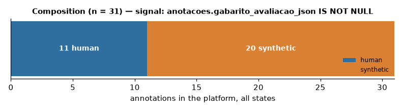

```
Material the tasks stand on, by provenance ('importada' = produced by the P4c generation campaign):
    rubricas           anotacao=1, fixture=12, importada=74
    respostas_modelo   fixture=24, importada=148
```

```python
if PRONTO:
    comp = geracao.composicao(conn)

    # Quais sintéticas JÁ foram avaliadas? Só sobre elas um agregado por
    # alvo/família pode ser publicado.
    sint_avaliadas = {r["anotacao_id"] for r in conn.execute(
        "SELECT av.anotacao_id FROM avaliacoes av "
        "JOIN anotacoes an ON an.id = av.anotacao_id "
        "WHERE an.gabarito_avaliacao_json IS NOT NULL")}
    n_sint = int(comp.get("sinteticas") or 0)
    n_pendentes = n_sint - len(sint_avaliadas)

    seguro = {k: v for k, v in comp.items()
              if k not in ("sinteticas_por_alvo", "sinteticas_por_familia")}
    print(json.dumps(seguro, indent=2, ensure_ascii=False))

    print(f"\nsynthetic items reviewed so far : {len(sint_avaliadas)} of {n_sint}")
    print(f"synthetic items still queued    : {n_pendentes}")
    if n_pendentes:
        print("\n  -> target-rating and defect-family breakdowns are WITHHELD from this")
        print("     notebook while any synthetic item is still awaiting review.")
        print("     They are in the database (and in `geracao.composicao`) — they are not")
        print("     printed into a committed HTML page that the reviewer can read.")
    else:
        print("\ntarget / defect-family distribution (all synthetic items already reviewed):")
        print(json.dumps({k: comp.get(k) for k in
                          ("sinteticas_por_alvo", "sinteticas_por_familia")},
                         indent=2, ensure_ascii=False))

    fig, ax = plt.subplots(figsize=(7.2, 2.0))
    h, s = int(comp.get("humanas") or 0), n_sint
    b1 = ax.barh(["annotations"], [h], color=AZUL, label="human")
    b2 = ax.barh(["annotations"], [s], left=[h], color=LARANJA, label="synthetic")
    ax.annotate(f"{h} human", (h / 2, 0), va="center", ha="center",
                color="white", weight="bold", fontsize=9)
    if s:
        ax.annotate(f"{s} synthetic", (h + s / 2, 0), va="center", ha="center",
                    color="white", weight="bold", fontsize=9)
    ax.set_xlim(0, h + s)
    ax.set_yticks([])
    ax.grid(False)
    ax.set_xlabel("annotations in the platform, all states")
    ax.set_title(f"Composition (n = {h + s}) — signal: {comp.get('sinal')}", fontsize=9.5)
    ax.legend(loc="lower right", frameon=False, fontsize=8)
    plt.tight_layout()
    mostrar(fig, "Single horizontal bar splitting all annotations in the platform into a human segment and a synthetic segment, each labelled with its count.")

    mat = comp.get("material_por_origem") or {}
    if mat:
        print("Material the tasks stand on, by provenance "
              "('importada' = produced by the P4c generation campaign):")
        for tabela, origens in mat.items():
            linha = ", ".join(f"{k}={v}" for k, v in sorted(origens.items()))
            print(f"    {tabela:<18} {linha}")
else:
    comp, sint_avaliadas, n_pendentes = {}, set(), 0
    print("skipped — no database")
```